# Biostat 203B Homework 5

```r
stopCluster(cl)
```

**Metrics for model stacking**

```r
st_auc <- yardstick::roc_auc(
  mimic_pred_auc,
  truth = los_long,
  contains(".pred_FALSE")
  )

st_acc <- yardstick::accuracy(
  mimic_pred_acc,
  truth = los_long,
  estimate = .pred_class
  )

st_metrics <- bind_rows(st_acc, st_auc) |>
  print()
```

```
# A tibble: 2 × 3
  .metric  .estimator .estimate
  <chr>    <chr>          <dbl>
1 accuracy binary         0.617
2 roc_auc  binary         0.661
```

**Final Results**

```r
results <- tibble(
  Model = c("Logistic Regression", "Random Forest",
            "XGBoost", "Model Stacking"),
  Accuracy = c(en_metrics$.estimate[1],
               rf_metrics$.estimate[1],
               gb_metrics$.estimate[1],
               st_metrics$.estimate[1]),
  ROC_AUC = c(en_metrics$.estimate[2],
              rf_metrics$.estimate[2],
              gb_metrics$.estimate[2],
              st_metrics$.estimate[2]),
) |>
  print()
```

```
# A tibble: 4 × 3
  Model               Accuracy ROC_AUC
  <chr>                  <dbl>   <dbl>
1 Logistic Regression    0.581   0.611
2 Random Forest          0.606   0.646
3 XGBoost                0.614   0.656
4 Model Stacking         0.617   0.661
```

**Predictor Importance in Predicting `los_long`**

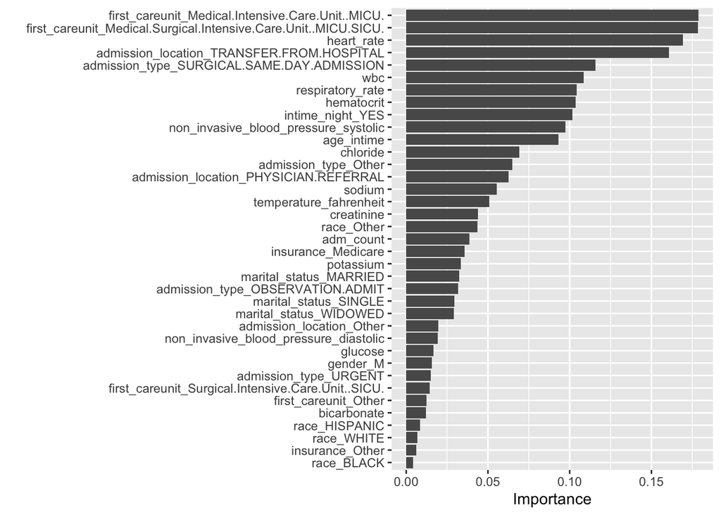

```r
library(rpart.plot)
library(vip)
## 1. Logistic Regression
 importance_en <- extract_workflow(final_en_fit) |>
  extract_fit_parsnip() |>
  vip(num_features = 38) |>
  print()
```

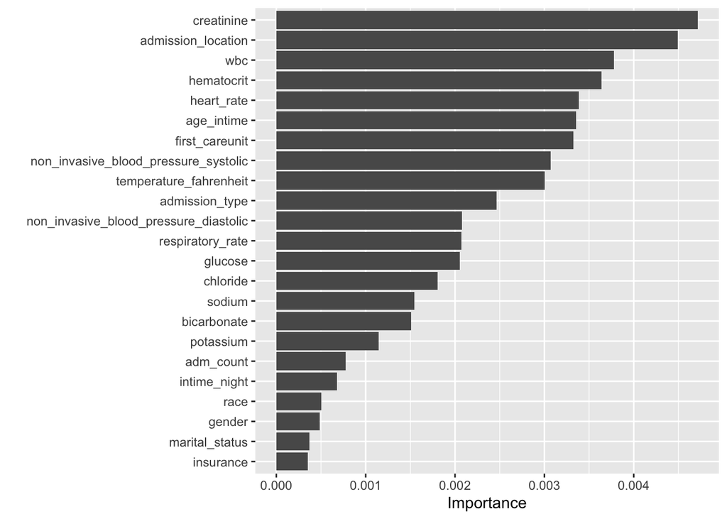

```r
## 2. Random Forest
importance_rf <- extract_workflow(final_rf_fit) |>
  extract_fit_parsnip() |>
  vip(num_features = 23) |>
  print()
```

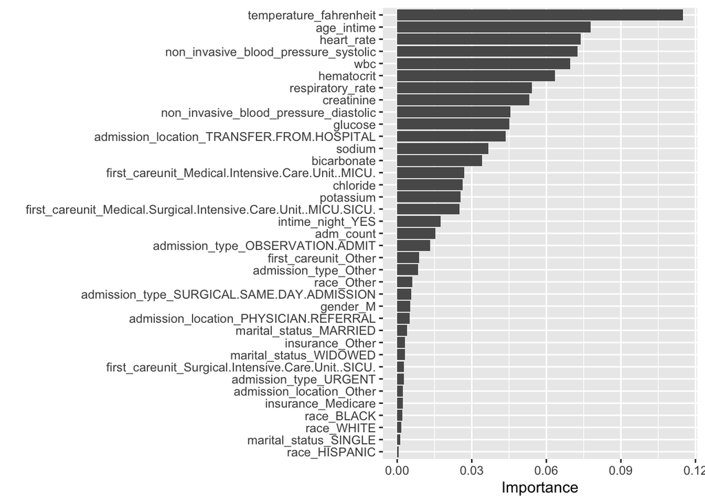

```r
## 3. XGBoost
importance_gb <- extract_workflow(final_gb_fit) |>
  extract_fit_parsnip() |>
  vip(num_features = 38) |>
  print()
```

4. Compare model classification performance on the test set. Report both the area under ROC curve and accuracy for each machine learning algorithm and the model stacking. Interpret the results. What are the most important features in predicting long ICU stays? How do the models compare in terms of performance and interpretability?